# Clasificación del Rendimiento Estudiantil

**Objetivo:** Construir un modelo de clasificación multiclase que prediga el nivel de rendimiento académico (bajo/medio/alto) a partir de hábitos de estudio, estilo de vida e indicadores de salud mental.

**Dataset:** [Student Performance Dataset](https://www.kaggle.com/datasets/amar5693/student-performance-dataset) — Kaggle

**Enfoque:** No se trata solo de conseguir la mayor accuracy posible, sino de razonar cada decisión: qué variables usar, qué problemas presentan los datos, y qué modelos tienen sentido para este problema.

## Inspección inicial de los datos

```python
import pandas as pd
import numpy as np
import matplotlib.pyplot as plt
import seaborn as sns
import warnings
warnings.filterwarnings('ignore')

df = pd.read_csv('student_dataset.csv')
print(f"Dimensiones: {df.shape[0]} filas × {df.shape[1]} columnas")
df.head()
```

```
Dimensiones: 5000 filas × 21 columnas
```

|  | student_id | age | gender | academic_level | study_hours | self_study_hours | online_classes_hours | social_media_hours | gaming_hours | sleep_hours | ... | exercise_minutes | caffeine_intake_mg | part_time_job | upcoming_deadline | internet_quality | mental_health_score | focus_index | burnout_level | productivity_score | exam_score |
| --- | --- | --- | --- | --- | --- | --- | --- | --- | --- | --- | --- | --- | --- | --- | --- | --- | --- | --- | --- | --- | --- |
| 0 | 1 | 18 | Other | High School | 7.64 | 1.56 | 2.20 | 3.05 | 2.19 | 6.52 | ... | 81 | 38 | 1 | 0 | Good | 10 | 43.05 | 31.77 | 73.65 | 50.16 |
| 1 | 2 | 18 | Other | High School | 2.21 | 2.22 | 2.10 | 1.65 | 2.55 | 5.97 | ... | 111 | 339 | 0 | 0 | Good | 3 | 15.92 | 37.00 | 13.70 | 1.00 |
| 2 | 3 | 22 | Male | High School | 3.45 | 0.00 | 0.29 | 1.34 | 2.08 | 8.39 | ... | 68 | 266 | 0 | 1 | Good | 8 | 27.39 | 34.37 | 45.15 | 18.30 |
| 3 | 4 | 17 | Other | High School | 5.75 | 2.08 | 3.01 | 2.27 | 2.20 | 6.31 | ... | 113 | 480 | 1 | 1 | Poor | 3 | 22.31 | 77.31 | 20.92 | 9.37 |
| 4 | 5 | 19 | Other | High School | 6.83 | 1.72 | 3.33 | 2.65 | 0.70 | 8.01 | ... | 121 | 24 | 1 | 0 | Good | 8 | 38.11 | 39.53 | 59.23 | 27.81 |

5 rows × 21 columns

### Tipos de datos y comprobación de nulos

```python
print("TIPOS DE DATOS:")
print(df.dtypes)
print(f"\nVALORES NULOS: {df.isnull().sum().sum()}")
print(f"FILAS DUPLICADAS: {df.drop(columns='student_id').duplicated().sum()}")
```

```
TIPOS DE DATOS:
student_id                int64
age                       int64
gender                      str
academic_level              str
study_hours             float64
self_study_hours        float64
online_classes_hours    float64
social_media_hours      float64
gaming_hours            float64
sleep_hours             float64
screen_time_hours       float64
exercise_minutes          int64
caffeine_intake_mg        int64
part_time_job             int64
upcoming_deadline         int64
internet_quality            str
mental_health_score       int64
focus_index             float64
burnout_level           float64
productivity_score      float64
exam_score              float64
dtype: object

VALORES NULOS: 0
FILAS DUPLICADAS: 0
```

No hay valores nulos ni filas duplicadas. El dataset tiene 3 variables categóricas (`gender`, `academic_level`, `internet_quality`), 2 binarias codificadas como enteros (`part_time_job`, `upcoming_deadline`) y el resto numéricas continuas. `student_id` es un identificador que descartaremos para el modelado.

### Análisis Exploratorio de Datos (EDA)

Empezaremos observando todas las distribuciones de todas las variables numéricas

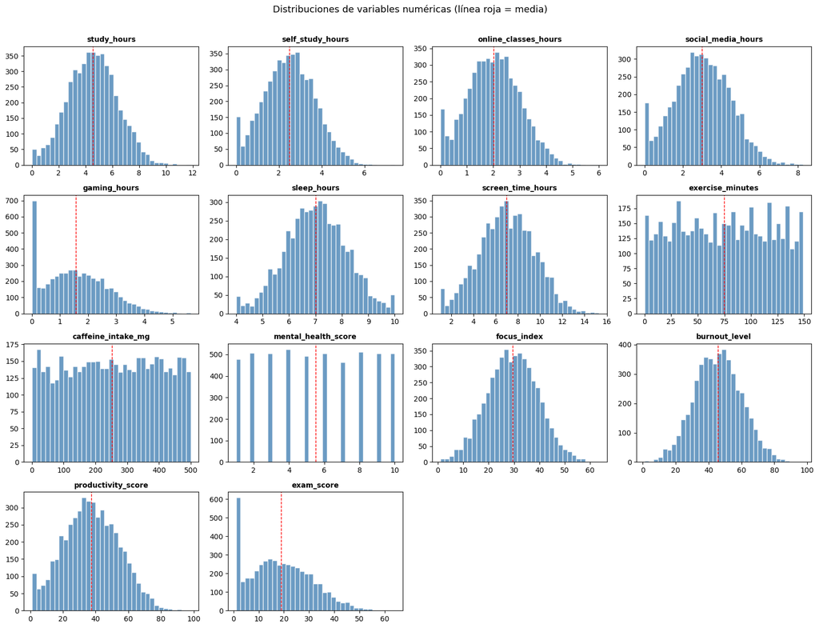

```python
continuous = ['study_hours', 'self_study_hours', 'online_classes_hours',
              'social_media_hours', 'gaming_hours', 'sleep_hours',
              'screen_time_hours', 'exercise_minutes', 'caffeine_intake_mg',
              'mental_health_score', 'focus_index', 'burnout_level',
              'productivity_score', 'exam_score']

fig, axes = plt.subplots(4, 4, figsize=(16, 12))
axes = axes.ravel()

for i, col in enumerate(continuous):
    axes[i].hist(df[col], bins=35, color='steelblue', edgecolor='white', alpha=0.8)
    axes[i].set_title(col, fontsize=10, fontweight='bold')
    axes[i].axvline(df[col].mean(), color='red', linestyle='--', linewidth=1)

for j in range(len(continuous), len(axes)):
    axes[j].set_visible(False)

plt.suptitle('Distribuciones de variables numéricas (línea roja = media)', fontsize=13, y=1.01)
plt.tight_layout()
plt.show()
```

Y ahora de las variables categóricas.

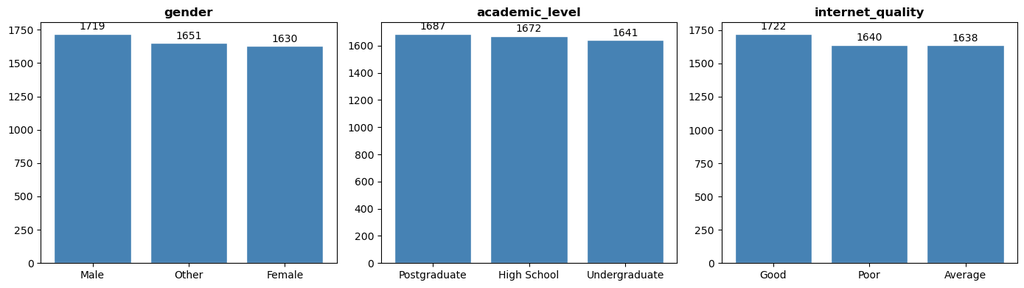

```python
fig, axes = plt.subplots(1, 3, figsize=(14, 4))

for ax, col in zip(axes, ['gender', 'academic_level', 'internet_quality']):
    counts = df[col].value_counts()
    ax.bar(counts.index, counts.values, color='steelblue', edgecolor='white')
    ax.set_title(col, fontweight='bold')
    for i, (val, cnt) in enumerate(counts.items()):
        ax.text(i, cnt + 30, str(cnt), ha='center', fontsize=10)

plt.tight_layout()
plt.show()
```

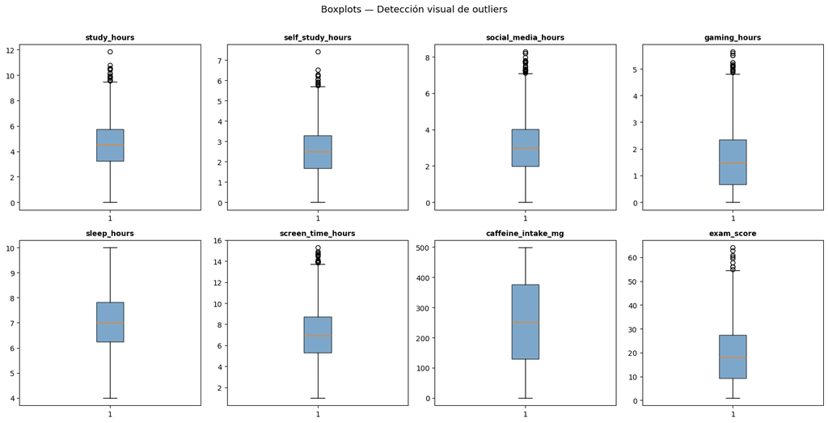

```python
fig, axes = plt.subplots(2, 4, figsize=(16, 8))
axes = axes.ravel()

box_cols = ['study_hours', 'self_study_hours', 'social_media_hours', 'gaming_hours',
            'sleep_hours', 'screen_time_hours', 'caffeine_intake_mg', 'exam_score']

for i, col in enumerate(box_cols):
    axes[i].boxplot(df[col], vert=True, patch_artist=True,
                    boxprops=dict(facecolor='steelblue', alpha=0.7))
    axes[i].set_title(col, fontweight='bold', fontsize=10)

plt.suptitle('Boxplots — Detección visual de outliers', fontsize=13, y=1.01)
plt.tight_layout()
plt.show()
```

### Observaciones del EDA visual

**Distribuciones numéricas:** La mayoría siguen distribuciones razonablemente normales o ligeramente sesgadas a la derecha. Destacan:

- `gaming_hours`: fuerte sesgo positivo, muchos estudiantes juegan poco
- `mental_health_score`: distribución uniforme (1-10), no normal
- `caffeine_intake_mg` y `exercise_minutes`: distribuciones uniformes, otro indicio de generación sintética
- `exam_score`: sesgo positivo, concentración en valores bajos (muchos estudiantes con notas bajas)

**Outliers:** Presentes pero moderados en `study_hours`, `self_study_hours`, `screen_time_hours` y `gaming_hours`. No parecen errores de medición sino valores extremos plausibles — por ahora no los eliminamos.

**Categóricas:** Las tres variables se reparten casi exactamente al 33%. Junto con las binarias al 50%, confirma que estamos ante un **dataset sintético**. Lo tendremos en cuenta al interpretar resultados.

### Matriz de correlaciones

Analizamos las correlaciones de Pearson entre todas las variables numéricas, incluyendo `exam_score` (nuestra futura variable objetivo, aún en formato continuo). Esto nos permite entender las relaciones lineales entre features y detectar posibles problemas antes de definir las categorías del target.

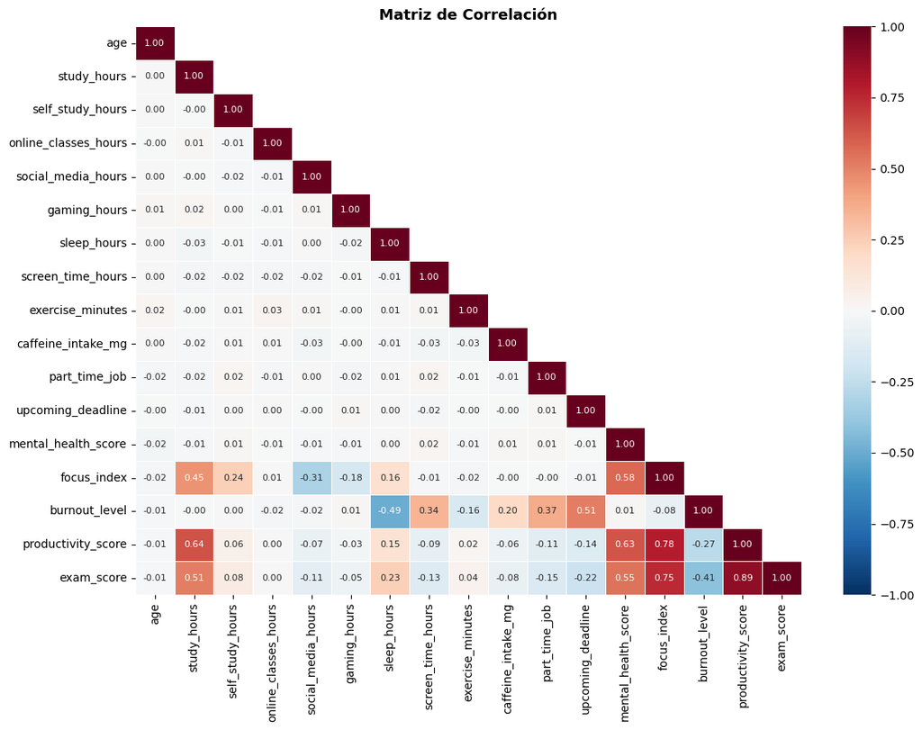

```python
num_cols = df.select_dtypes(include=[np.number]).columns.drop('student_id')

fig, ax = plt.subplots(figsize=(12, 9))
corr = df[num_cols].corr()
mask = np.triu(np.ones_like(corr, dtype=bool), k=1)
sns.heatmap(corr, mask=mask, annot=True, fmt='.2f', cmap='RdBu_r',
            center=0, vmin=-1, vmax=1, ax=ax, linewidths=0.5,
            annot_kws={'size': 8})
ax.set_title('Matriz de Correlación', fontsize=13, fontweight='bold')
plt.tight_layout()
plt.show()
```

La matriz muestra un patrón que divide claramente las variables en dos grupos:

**Grupo 1 — Variables con correlaciones muy bajas entre sí (< 0.03):** Son la mayoría de features del dataset (horas de estudio, sueño, gaming, redes sociales, edad, etc.). Que no correlacionen nada entre sí es otro indicio de que el dataset es sintético y que en datos reales esperaríamos cierta relación entre, por ejemplo, horas de gaming y horas de pantalla.

**Grupo 2 — Variables con correlaciones altas entre sí y con `exam_score`:**

- `productivity_score` → 0.89 con `exam_score`
- `focus_index` → 0.75 con `exam_score`
- `mental_health_score` → 0.55 con `exam_score`
- `burnout_level` → -0.41 con `exam_score`

**¿Por qué es relevante?** Una correlación de 0.89 es excepcionalmente alta para un problema de predicción. Esto levanta una sospecha: ¿`productivity_score` y `focus_index` son variables que realmente se conocen *antes* del examen, o se han calculado *a partir* del resultado? Si fuera lo segundo, estaríamos ante un caso de **data leakage** (usar información del futuro para predecir), lo cual inflaría artificialmente el rendimiento del modelo.

Vamos a investigar esto con más detalle antes de tomar decisiones sobre qué features incluir en el modelado.

## Data Leakage

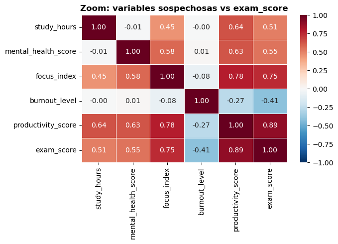

```python
suspect = ['study_hours', 'mental_health_score', 'focus_index',
           'burnout_level', 'productivity_score', 'exam_score']

fig, ax = plt.subplots(figsize=(7, 5))
sns.heatmap(df[suspect].corr(), annot=True, fmt='.2f', cmap='RdBu_r',
            center=0, vmin=-1, vmax=1, ax=ax, linewidths=0.5)
ax.set_title('Zoom: variables sospechosas vs exam_score', fontweight='bold')
plt.tight_layout()
plt.show()
```

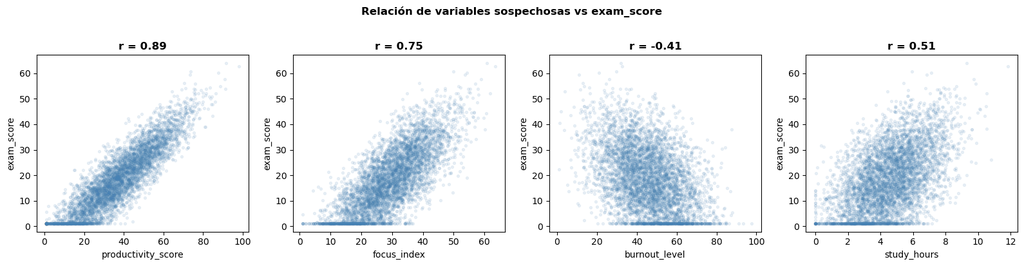

```python
fig, axes = plt.subplots(1, 4, figsize=(16, 4))

for ax, col in zip(axes, ['productivity_score', 'focus_index', 'burnout_level', 'study_hours']):
    ax.scatter(df[col], df['exam_score'], alpha=0.1, s=8, color='steelblue')
    ax.set_xlabel(col)
    ax.set_ylabel('exam_score')
    ax.set_title(f'r = {df[col].corr(df["exam_score"]):.2f}', fontweight='bold')

plt.suptitle('Relación de variables sospechosas vs exam_score', y=1.02, fontweight='bold')
plt.tight_layout()
plt.show()
```

Los scatter plots confirman las sospechas:

- **`productivity_score`** (r=0.89): relación casi lineal con `exam_score`. Es muy improbable que una variable medida *antes* del examen prediga la nota con esta precisión. Todo apunta a que es una variable derivada o calculada a posteriori.
- **`focus_index`** (r=0.75): patrón similar aunque con más dispersión.
- **`burnout_level`** (r=-0.41): correlación negativa moderada, más plausible como predictor real.
- **`study_hours`** (r=0.51): dispersión mucho mayor, comportamiento típico de un predictor legítimo.

Además, `productivity_score` correlaciona 0.78 con `focus_index` y 0.63 con `mental_health_score`, lo que sugiere que estas variables comparten una estructura subyacente común — probablemente generada a partir del target.

**Decisión:** Para asegurarnos entrenaremos modelos en **dos escenarios**:

1. **Escenario completo:** todas las features (para ver el techo de rendimiento)
2. **Escenario realista:** excluyendo `productivity_score` y `focus_index` (simulando un caso donde solo disponemos de variables que un estudiante reportaría antes del examen)

La comparación entre ambos escenarios será en sí misma un hallazgo interesante del análisis.

## Definición de la variable objetivo

Nuestro target original (`exam_score`) es continuo. Para convertirlo en un problema de clasificación, necesitamos discretizarlo en categorías. Vamos a analizar cómo dividirlo antes de decidir los umbrales.

```python
print("Percentiles de exam_score:")
for p in [25, 33, 50, 66, 75]:
    print(f"  P{p}: {df['exam_score'].quantile(p/100):.2f}")

print(f"\nMedia: {df['exam_score'].mean():.2f}")
print(f"Mediana: {df['exam_score'].median():.2f}")
```

```
Percentiles de exam_score:
  P25: 9.34
  P33: 12.32
  P50: 18.01
  P66: 23.71
  P75: 27.40

Media: 18.80
Mediana: 18.01
```

Dividimos `exam_score` en tres categorías usando terciles (percentiles 33 y 66), lo que garantiza clases aproximadamente equilibradas. Esto nos permite:

- Usar **accuracy** como métrica sin que sea engañosa por desbalance
- Comparar modelos de forma justa entre las tres clases
- Evitar técnicas de resampling que añadirían complejidad innecesaria en esta fase

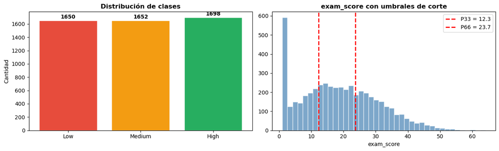

```python
fig, axes = plt.subplots(1, 2, figsize=(13, 4))

# Distribución de clases
colors = {'Low': '#E74C3C', 'Medium': '#F39C12', 'High': '#27AE60'}
counts = df['performance'].value_counts().reindex(['Low', 'Medium', 'High'])
bars = axes[0].bar(counts.index, counts.values, color=[colors[c] for c in counts.index], edgecolor='white')
for bar, val in zip(bars, counts.values):
    axes[0].text(bar.get_x() + bar.get_width()/2, bar.get_height() + 30, str(val), ha='center', fontweight='bold')
axes[0].set_title('Distribución de clases', fontweight='bold')
axes[0].set_ylabel('Cantidad')

# Histograma con los cortes
axes[1].hist(df['exam_score'], bins=40, color='steelblue', edgecolor='white', alpha=0.7)
axes[1].axvline(q33, color='red', linestyle='--', linewidth=2, label=f'P33 = {q33:.1f}')
axes[1].axvline(q66, color='red', linestyle='--', linewidth=2, label=f'P66 = {q66:.1f}')
axes[1].set_title('exam_score con umbrales de corte', fontweight='bold')
axes[1].set_xlabel('exam_score')
axes[1].legend()

plt.tight_layout()
plt.show()
```

## Relación entre features y la variable objetivo

Ahora que tenemos el target definido, vamos a analizar cómo se distribuyen las features principales dentro de cada clase. Esto nos dará intuición sobre qué variables tendrán más poder predictivo.

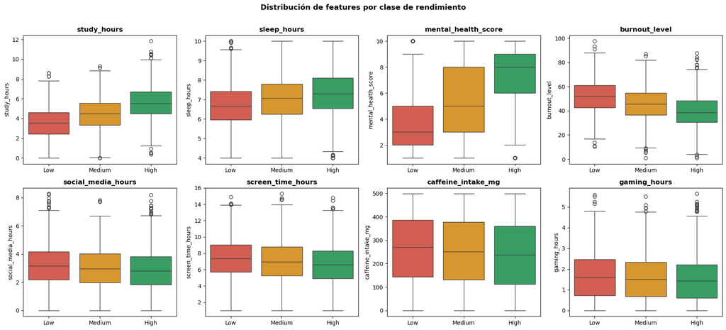

```python
feat_cols = ['study_hours', 'sleep_hours', 'mental_health_score', 'burnout_level',
             'social_media_hours', 'screen_time_hours', 'caffeine_intake_mg', 'gaming_hours']

fig, axes = plt.subplots(2, 4, figsize=(18, 8))
axes = axes.ravel()
order = ['Low', 'Medium', 'High']
palette = {'Low': '#E74C3C', 'Medium': '#F39C12', 'High': '#27AE60'}

for i, col in enumerate(feat_cols):
    sns.boxplot(data=df, x='performance', y=col, order=order,
                palette=palette, ax=axes[i])
    axes[i].set_title(col, fontweight='bold')
    axes[i].set_xlabel('')

plt.suptitle('Distribución de features por clase de rendimiento', fontsize=13, fontweight='bold', y=1.01)
plt.tight_layout()
plt.show()
```

## Análisis del Boxplot: Distribución de features por clase de rendimiento

### Features con alta capacidad discriminativa

**`study_hours`** — Separación clara entre clases

**`mental_health_score`** — Separación muy clara

- Low: mediana ~3, High: mediana ~8
- Las cajas de Low y High casi no se solapan → **predictor fuerte**

**`sleep_hours`** — Tendencia positiva moderada

- Low (~6.8h) → Medium (~7h) → High (~7.5h)
- Solapamiento considerable, pero hay tendencia → **predictor moderado**

**`burnout_level`** — Tendencia negativa clara

- Low: mediana ~55, High: mediana ~40
- Los estudiantes de alto rendimiento tienen **menos burnout** → **buen predictor**

### Features con baja capacidad discriminativa

**`social_media_hours`** — Casi sin diferencia → **predictor débil**

**`screen_time_hours`** — Sin patrón claro → **predictor muy débil**

**`caffeine_intake_mg`** — Sin diferencia apreciable → **no discrimina**

**`gaming_hours`** — Sin diferencia apreciable → **no discrimina**

### Conclusión

| Utilidad | Features |
| --- | --- |
| Alta | `mental_health_score`, `study_hours`, `burnout_level` |
| Moderada | `sleep_hours` |
| Baja/nula | `social_media_hours`, `screen_time_hours`, `caffeine_intake_mg`, `gaming_hours` |